# ingressWeb

Sigbert Ingress

2018-03-18

## Creating portal positions

### Real world portals

You can store portal longitude and latitude data in a data frame to use them in fielding.

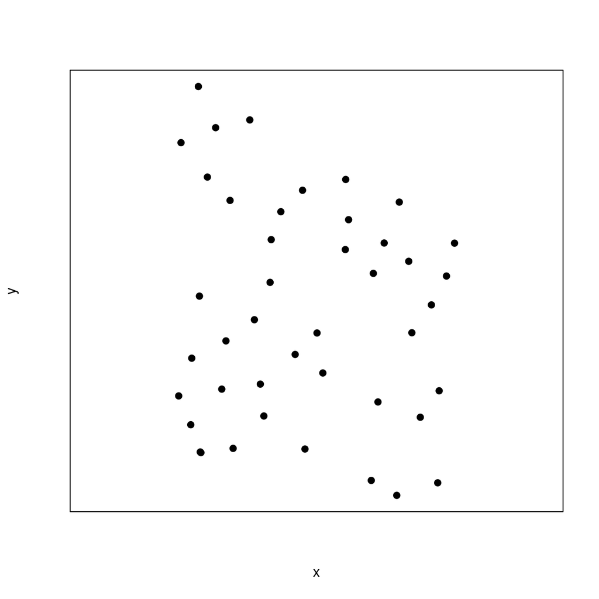

```r
library(ingressWeb)
# Read portal position from a Excel CSV file
path     <- system.file('shiny', 'data', package='ingressWeb')
filename <- paste(path, 'Leisepark-170212.csv', sep='/')
portals  <- read.csv(filename, stringsAsFactors = FALSE)
# convert latitude and longitude to x-y coordinates using the
# Universal Transverse Mercator coordinate system
xy       <- ll2xy(portals, utm=33)
web      <- ingressWeb(xy)
plot(web)
```

### Random positions

`random2` creates `n` portal positions. The last three portals form a outer triangle which consists all other portals.

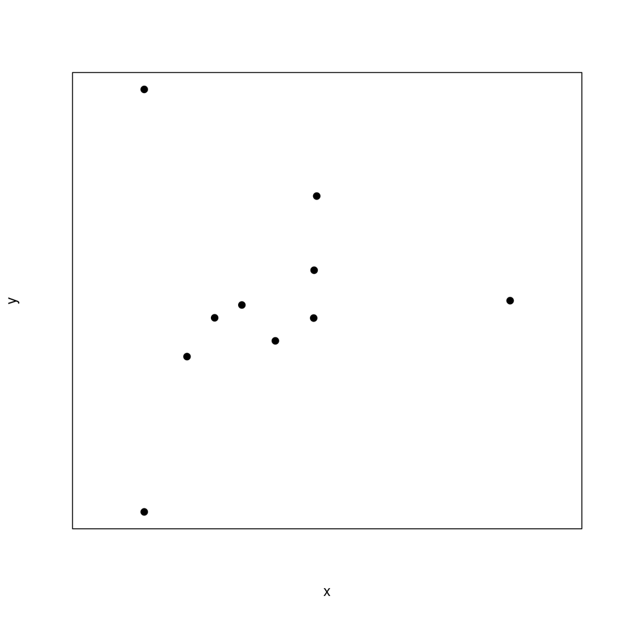

```r
set.seed(0)
library(ingressWeb)
web <- ingressWeb(random2(10))
plot(web)
```

The positions are generated from univariate random functions which are called twice. The parameter `d` is multiplicator which determines the distance of the outer portals. If `d` is smaller than `1` then the three other portals might not be outer portals anymore.

The parameter `random` is the univariate random generator function, the default is `rnorm`. The `...` may contain further parameters for the random generator function. As default the random portal positions are generated from an independent bivariate standard normal distribution.

The following code generates the portal positions from an independent bivariate uniform distribution.

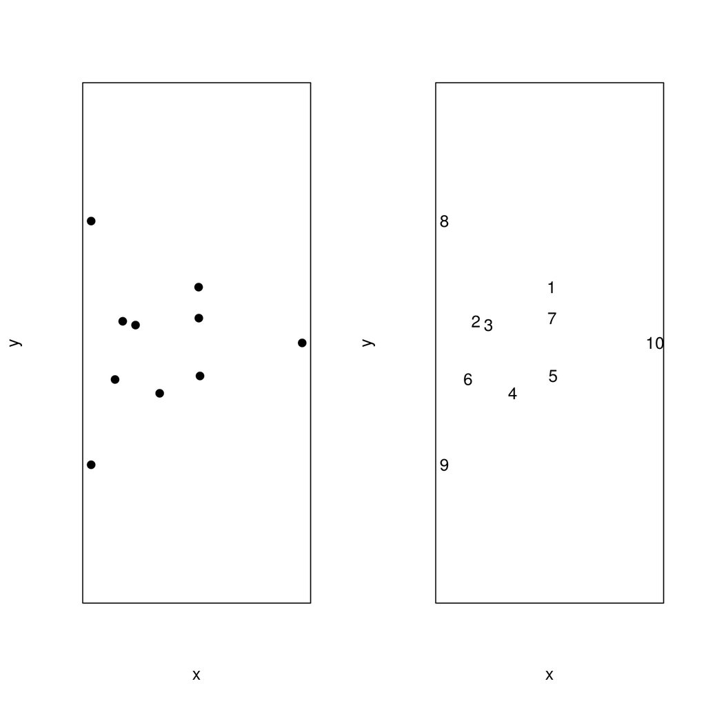

```r
set.seed(0)
library(ingressWeb)
web <- ingressWeb(random2(10, random=runif))
par(mfrow=c(1,2))
plot(web)
plot(web, text=TRUE, col="white") # show portal index rather than points
```

### Cobweb

`cobweb` creates `n` portal positions for each leg of a Cobweb.

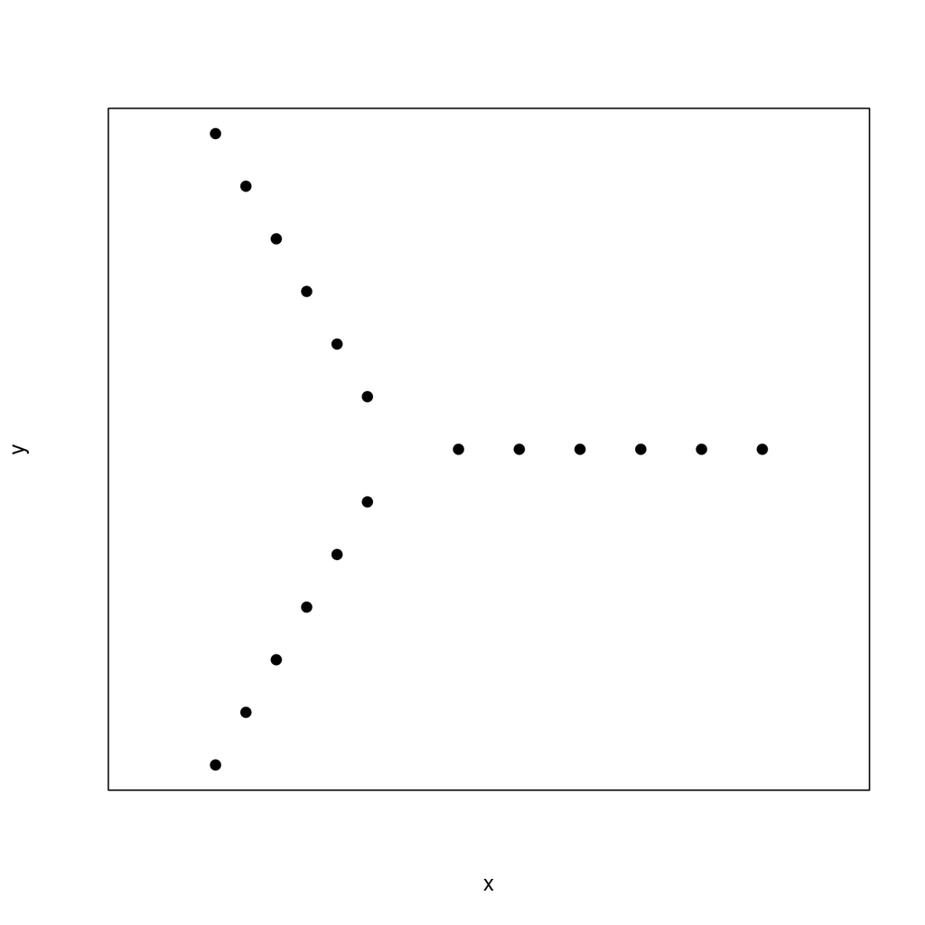

```r
library(ingressWeb)
web <- ingressWeb(cobweb(6))
plot(web)
```

The parameter `d` distorts each position by a uniform number in the interval `[-d;d]`. In the real world you will not get such nice portal positions for a cobweb.

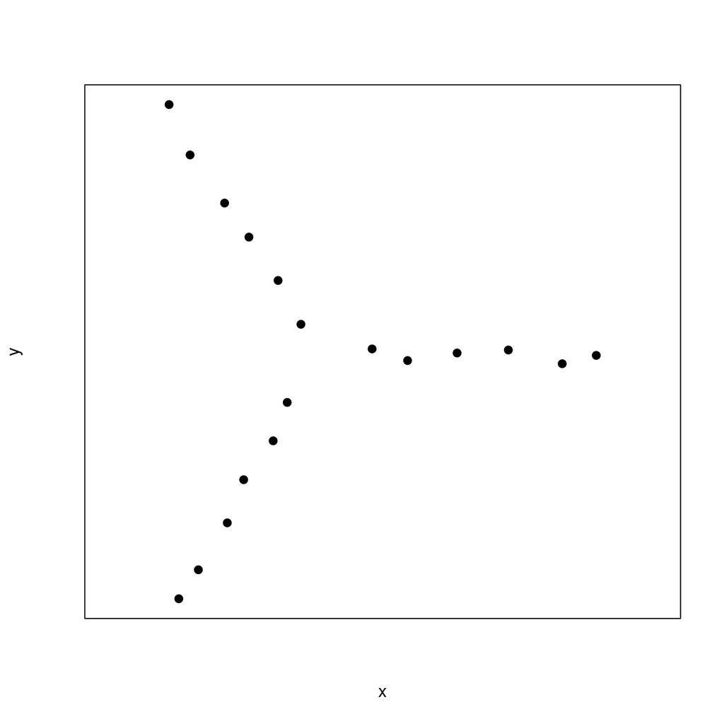

```r
set.seed(0)
library(ingressWeb)
web <- ingressWeb(cobweb(6, d=0.2))
plot(web)
```

### Herring/Fish bone

`fishbone` creates `n` portal positions for a fish bone web.

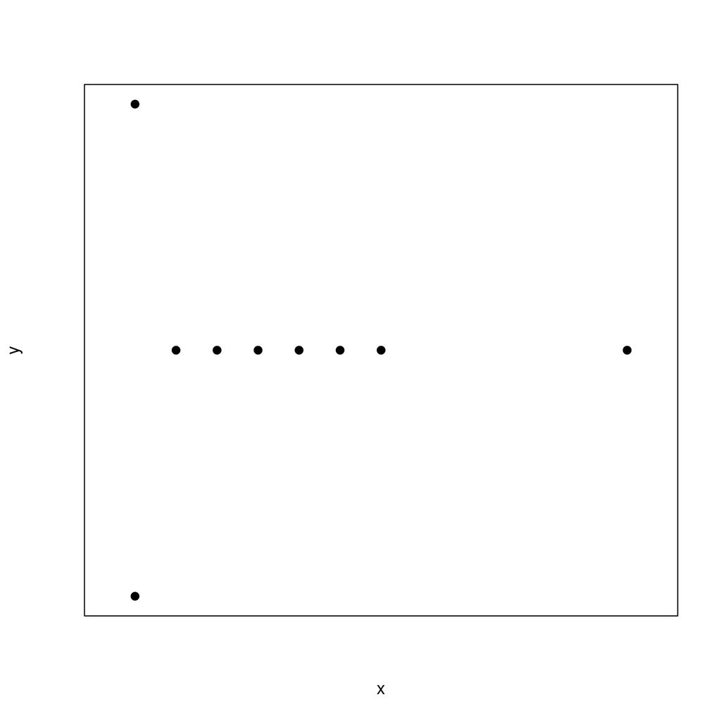

```r
library(ingressWeb)
web <- ingressWeb(fishbone(9))
plot(web)
```

The parameter `d` distorts each position by a uniform number in the interval `[-d;d]`. In the real world you will not get such nice portal positions for fish bone web.

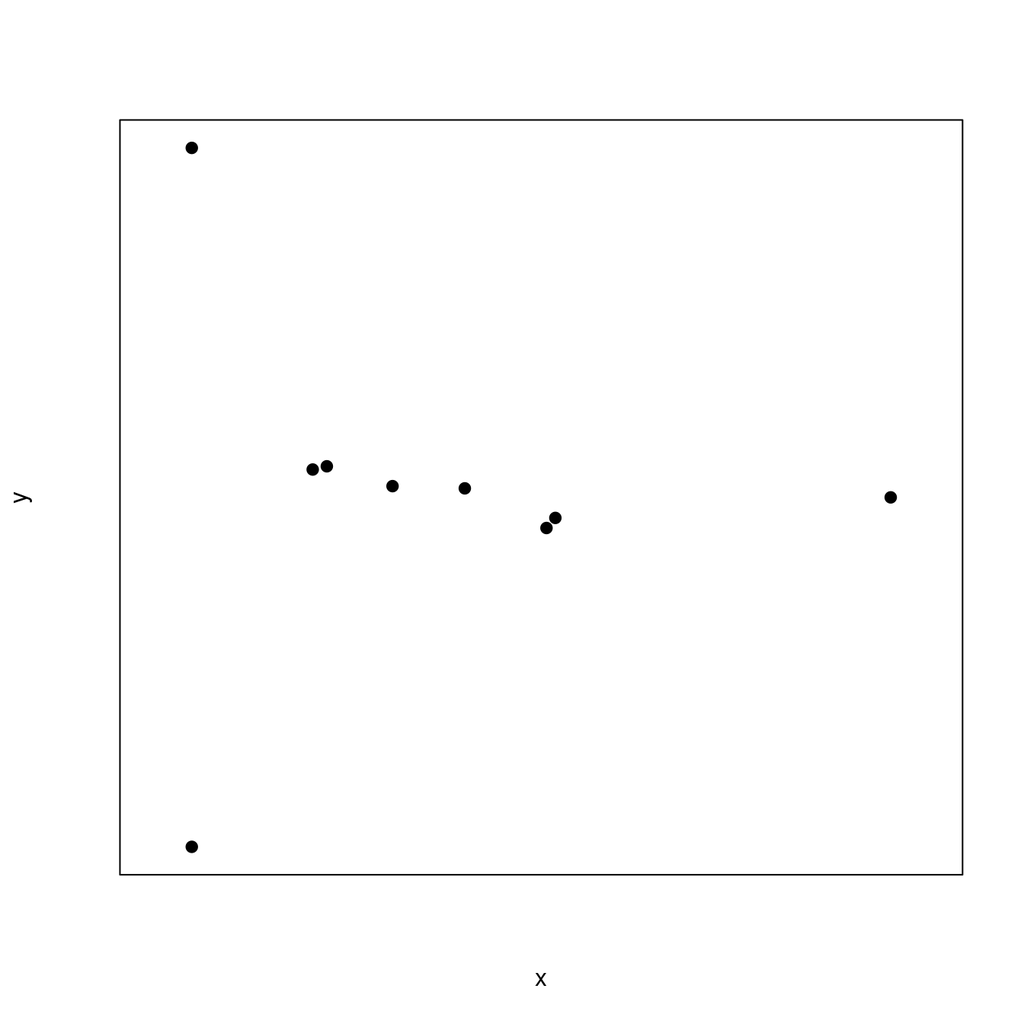

```r
set.seed(0)
library(ingressWeb)
web <- ingressWeb(fishbone(9, d=0.2))
plot(web)
```

## Creating a full web

Once a web with portal positions has been created it is necessary to link the portals after some specific link plan. `make.links` creates links following some link plan. Except for the Delaunay plan, the default, it necessary to give a named parameter which also tells which link plan has to followed.

### Delaunay web

The Delaunay web contains usually at maximum one multilayer. For the Delaunay web use

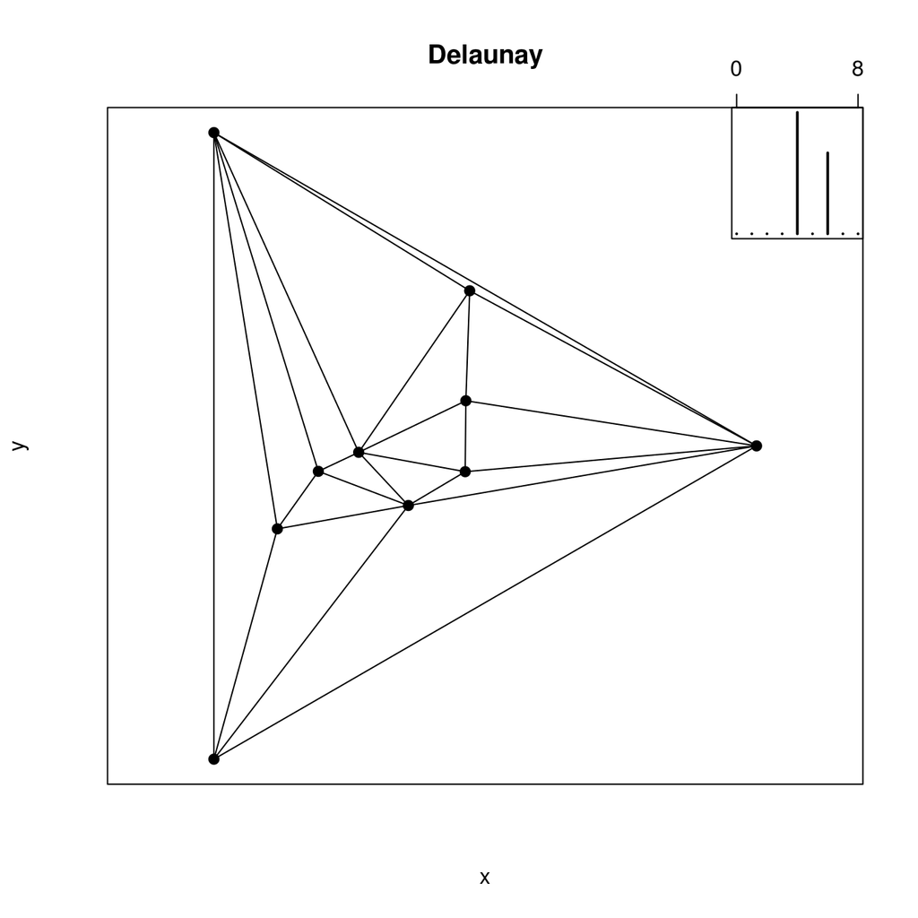

```r
set.seed(0)
library(ingressWeb)
web  <- ingressWeb(random2(10))
webd <- make.links(web)
plot(webd, main="Delaunay", pos='topright')
```

### MaxArea web

The MaxArea web maximizes the mind units (MU) you receive. Since the MUs are proportional to the area a field covers, the algorithm tries to maximize the area covered by the fields.

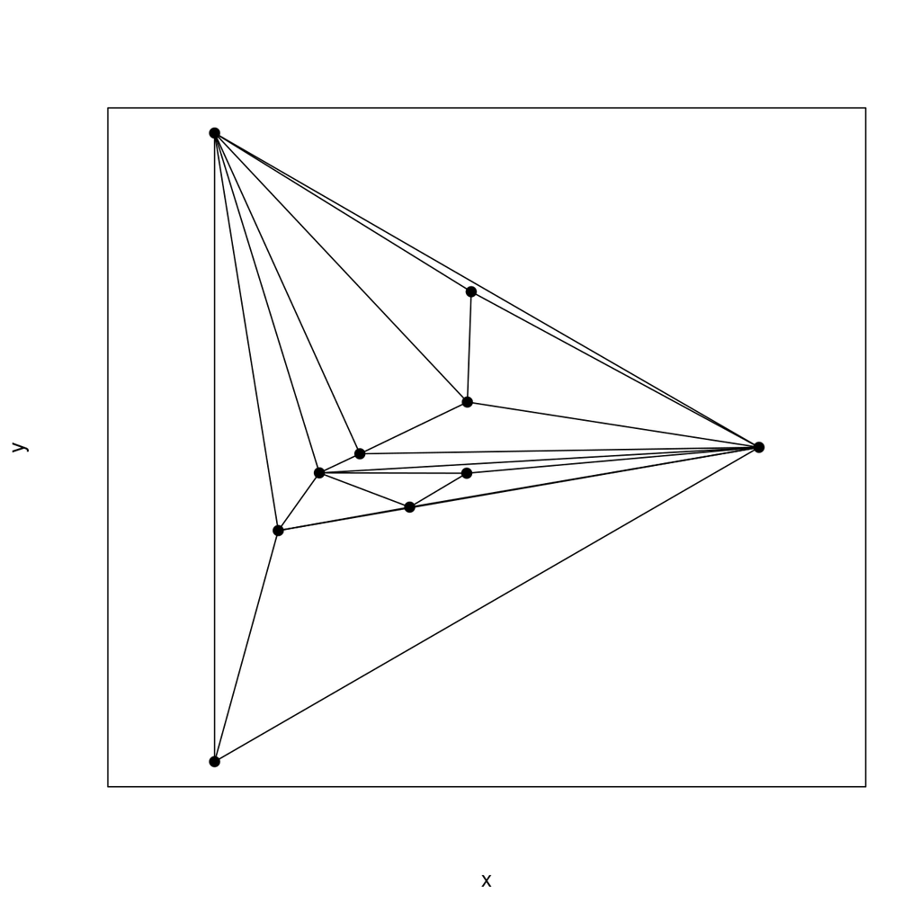

```r
set.seed(0)
library(ingressWeb)
web <- ingressWeb(random2(10))
fullweb <- make.links(web, maxarea=10)
plot(fullweb)
```

### Herring/Fish bone web

For the fish bone use

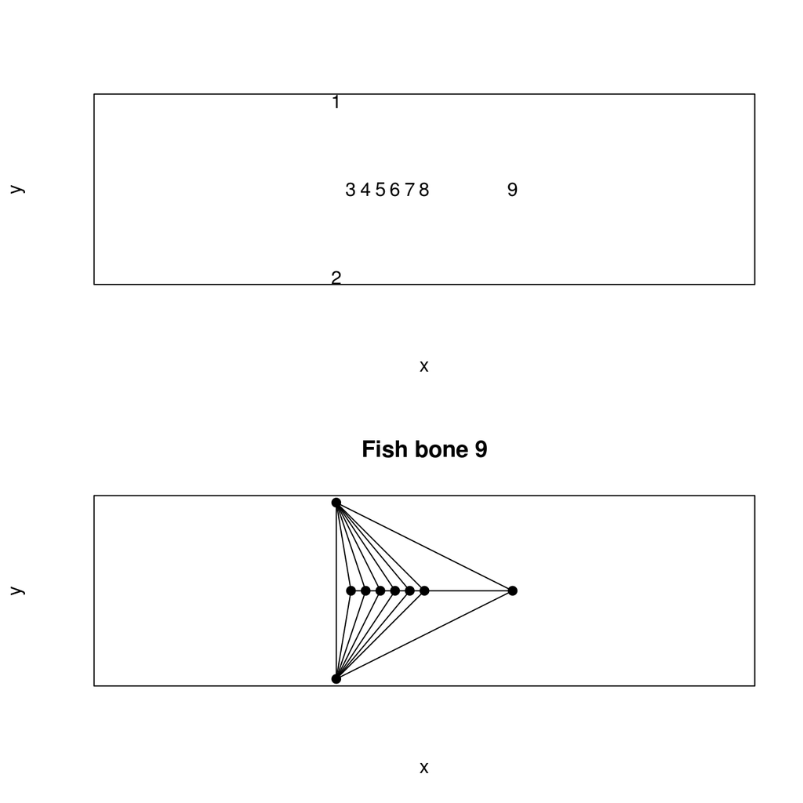

```r
library(ingressWeb)
web <- ingressWeb(fishbone(9))
web9 <- make.links(web, fishbone=9)
par(mfrow=c(2,1))
plot(web, text=TRUE, col="white")
plot(web9, main="Fish bone 9")
```

### Fanfield web

For the Fanfield use

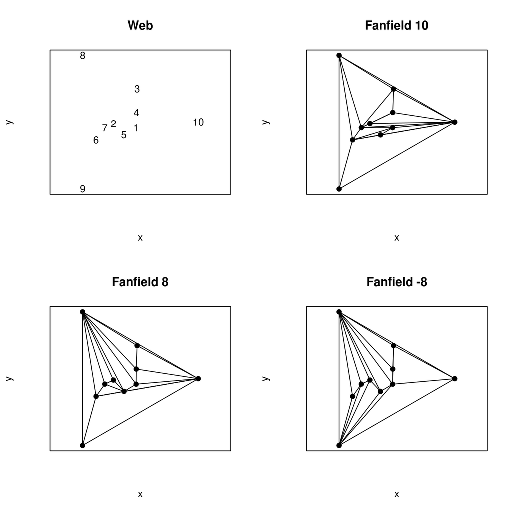

```r
set.seed(0)
library(ingressWeb)
web <- ingressWeb(random2(10))
web1 <- make.links(web, fanfield=10)
web2 <- make.links(web, fanfield=8)
web3 <- make.links(web, fanfield=-8)
par(mfrow=c(2,2))
plot(web, main="Web", text=TRUE, col="white")
plot(web1, main="Fanfield 10")
plot(web2, main="Fanfield 8")
plot(web3, main="Fanfield -8")
```

### Cobweb

For the Cobweb use

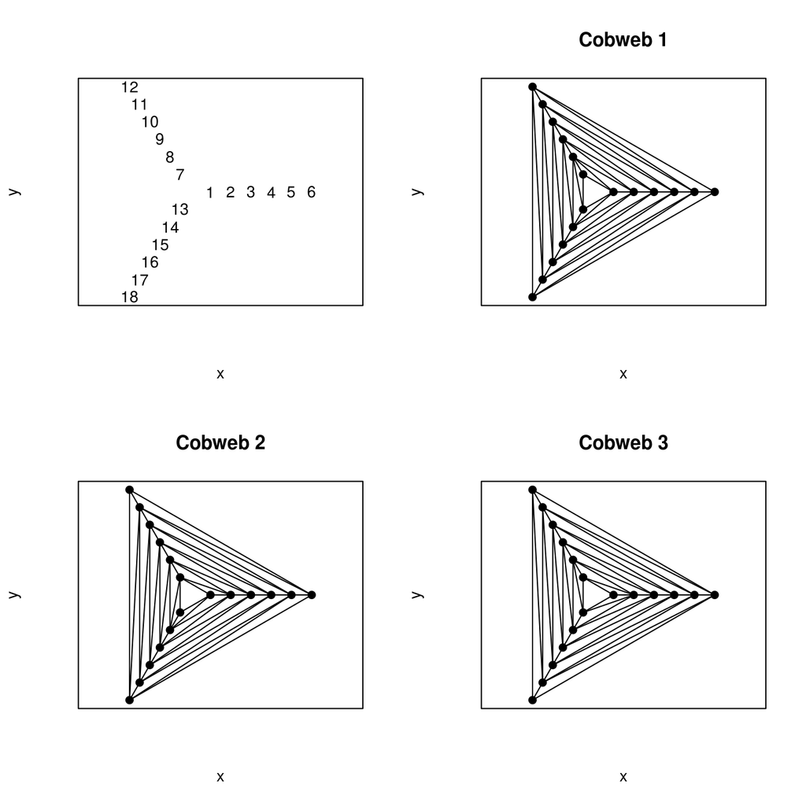

```r
library(ingressWeb)
web <- ingressWeb(cobweb(6))
web1 <- make.links(web, cobweb=6)
web2 <- make.links(web, cobweb=12)
web3 <- make.links(web, cobweb=18)
par(mfrow=c(2,2))
plot(web, text=TRUE, col=0)
plot(web1, main="Cobweb 1")
plot(web2, main="Cobweb 2")
plot(web3, main="Cobweb 3")
```

The `cobweb` parameter determines at which outer portal the algorithm starts. At a first glance the cob webs look very similar, but in fact the linking structure is different.

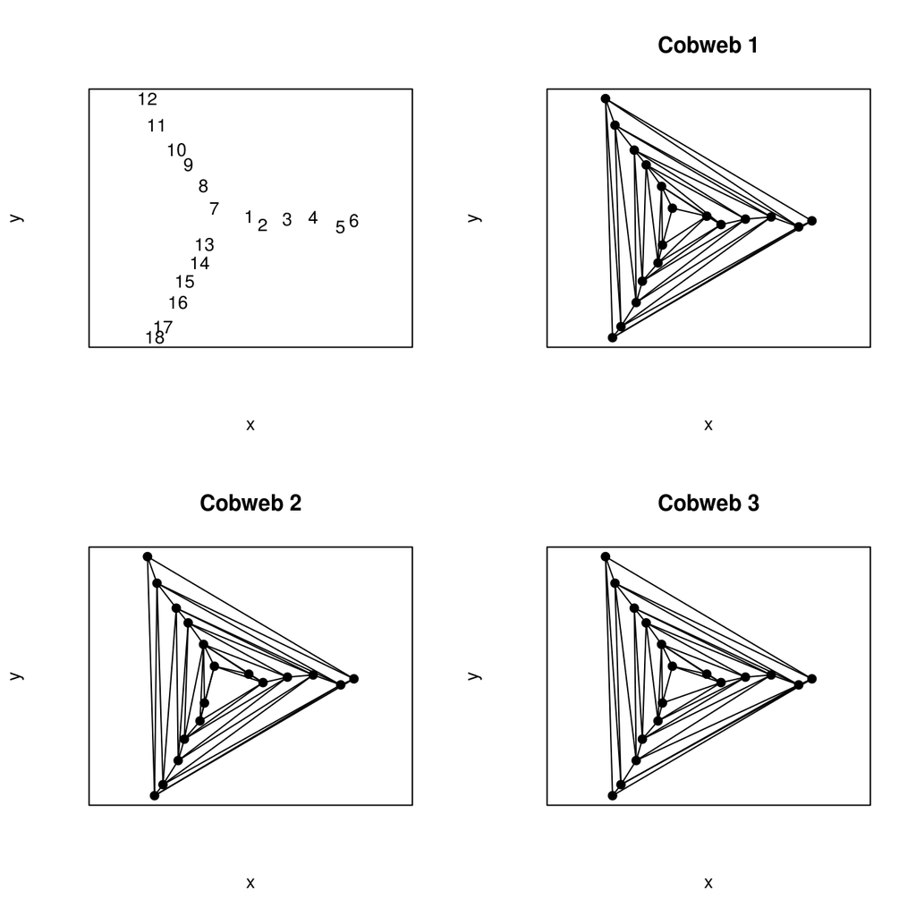

```r
set.seed(0)
library(ingressWeb)
web <- ingressWeb(cobweb(6, 0.3))
web1 <- make.links(web, cobweb=6)
web2 <- make.links(web, cobweb=12)
web3 <- make.links(web, cobweb=18)
par(mfrow=c(2,2))
plot(web, text=TRUE, col=0)
plot(web1, main="Cobweb 1")
plot(web2, main="Cobweb 2")
plot(web3, main="Cobweb 3")
```

## Creating a full web with real world portals

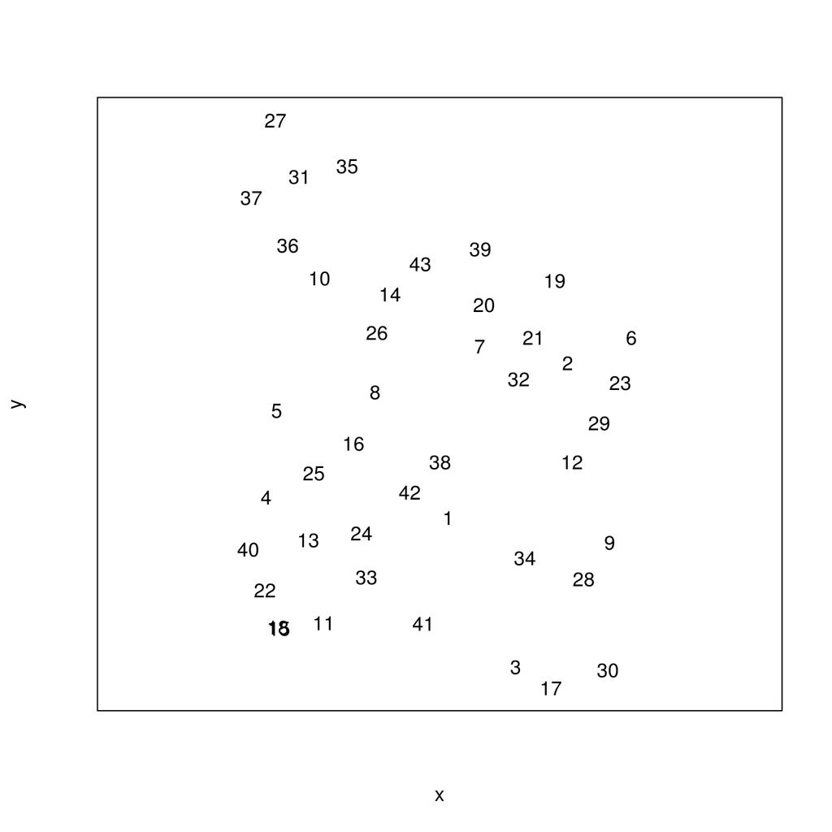

```r
library(ingressWeb)
# Read portal position from a Excel CSV file
path     <- system.file('shiny', 'data', package='ingressWeb')
filename <- paste(path, 'Leisepark-170212.csv', sep='/')
portals  <- read.csv(filename)
# convert latitude and longitude to x-y coordinates using the
# Universal Transverse Mercator coordinate system
xy       <- ll2xy(portals, utm=33)
web      <- ingressWeb(xy)
plot(web, text=TRUE, col="white")
```

### Triangulation web

One problem that you encounter (except for the Delaunay web) is that most linking plans require three outer portals which form a triangle. Unfortunately in the real world a portal set does not form a triangular shape. Therefore we compute the convex hull, choose an inner portal and decompose portal set into a set or triangular areas where the choosen linking plan can be applied.

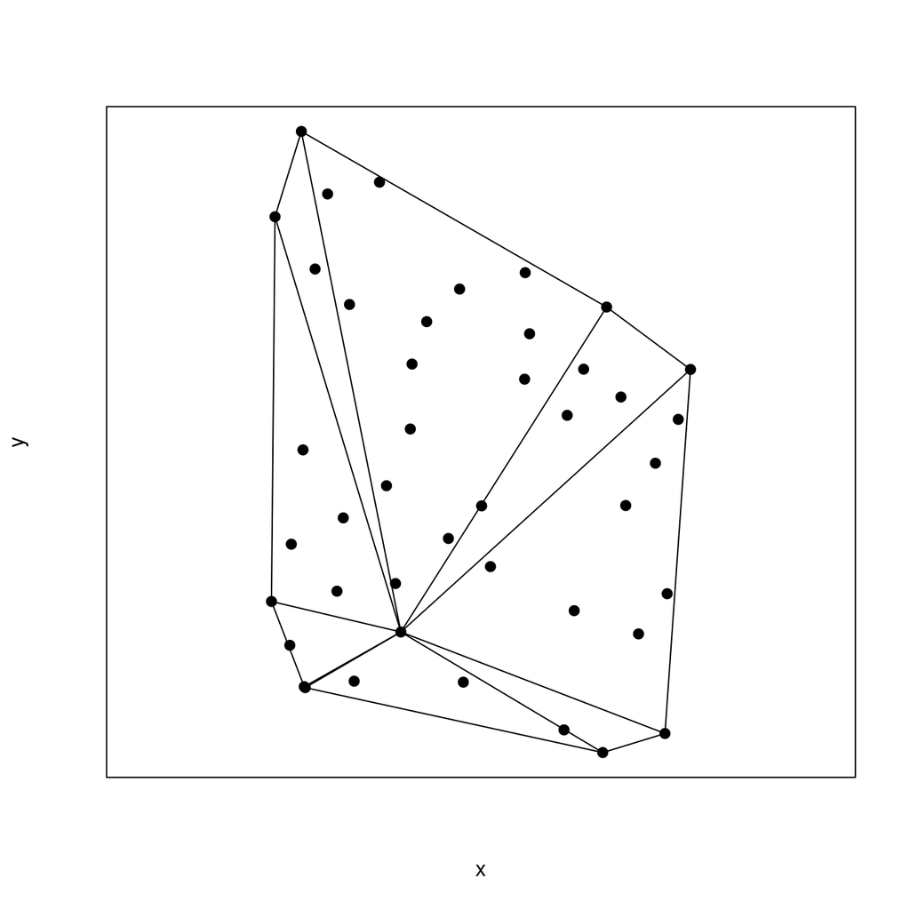

```r
library(ingressWeb)
# Read portal position from a Excel CSV file
path     <- system.file('shiny', 'data', package='ingressWeb')
filename <- paste(path, 'Leisepark-170212.csv', sep='/')
portals  <- read.csv(filename)
# convert latitude and longitude to x-y coordinates using the
# Universal Transverse Mercator coordinate system
xy     <- ll2xy(portals, utm=33)
web    <- ingressWeb(xy)
webtri <- make.links(web, triangle=33)
plot(webtri)
```

### Delaunay web

The Delaunay web is only web that does not require partinioning the portals before applying a linking plan.

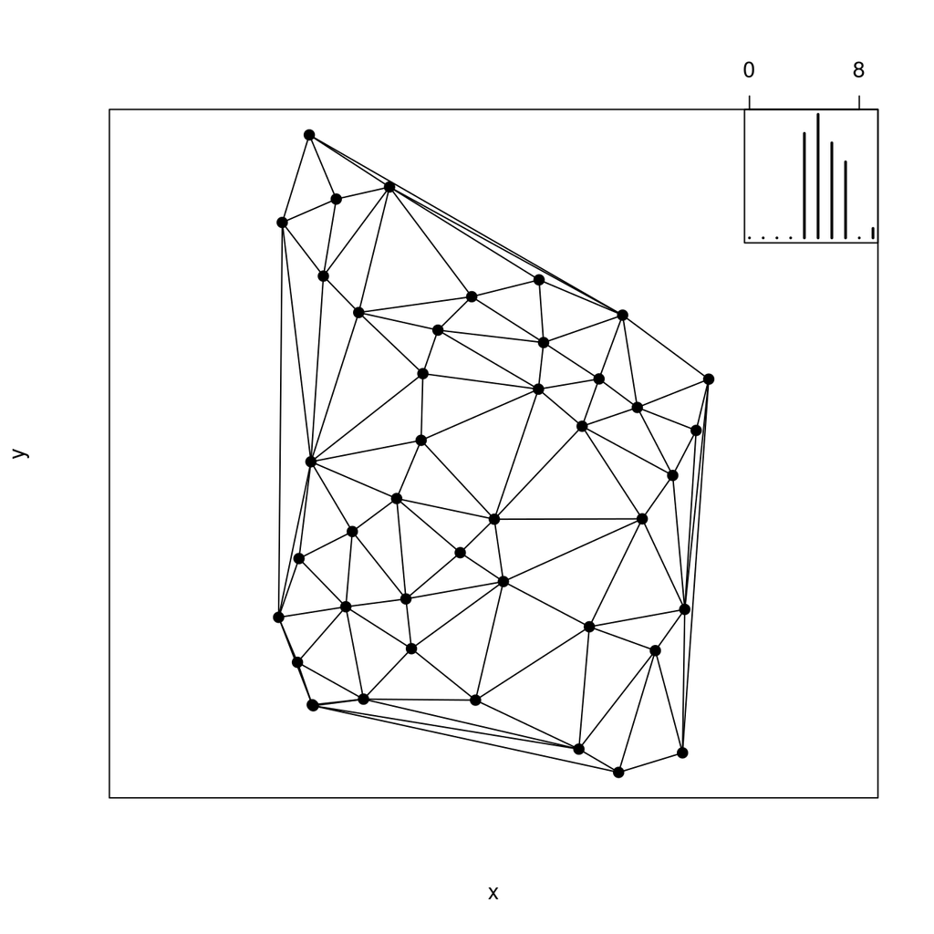

```r
library(ingressWeb)
# Read portal position from a Excel CSV file
path     <- system.file('shiny', 'data', package='ingressWeb')
filename <- paste(path, 'Leisepark-170212.csv', sep='/')
portals  <- read.csv(filename)
# convert latitude and longitude to x-y coordinates using the
# Universal Transverse Mercator coordinate system
xy   <- ll2xy(portals, utm=33)
web  <- ingressWeb(xy)
webd <- make.links(web)
plot(webd, pos="topright")
```

### Other webs

At first the more easy plans, e.g. Fish bone, Fanfiled and Maxarea:

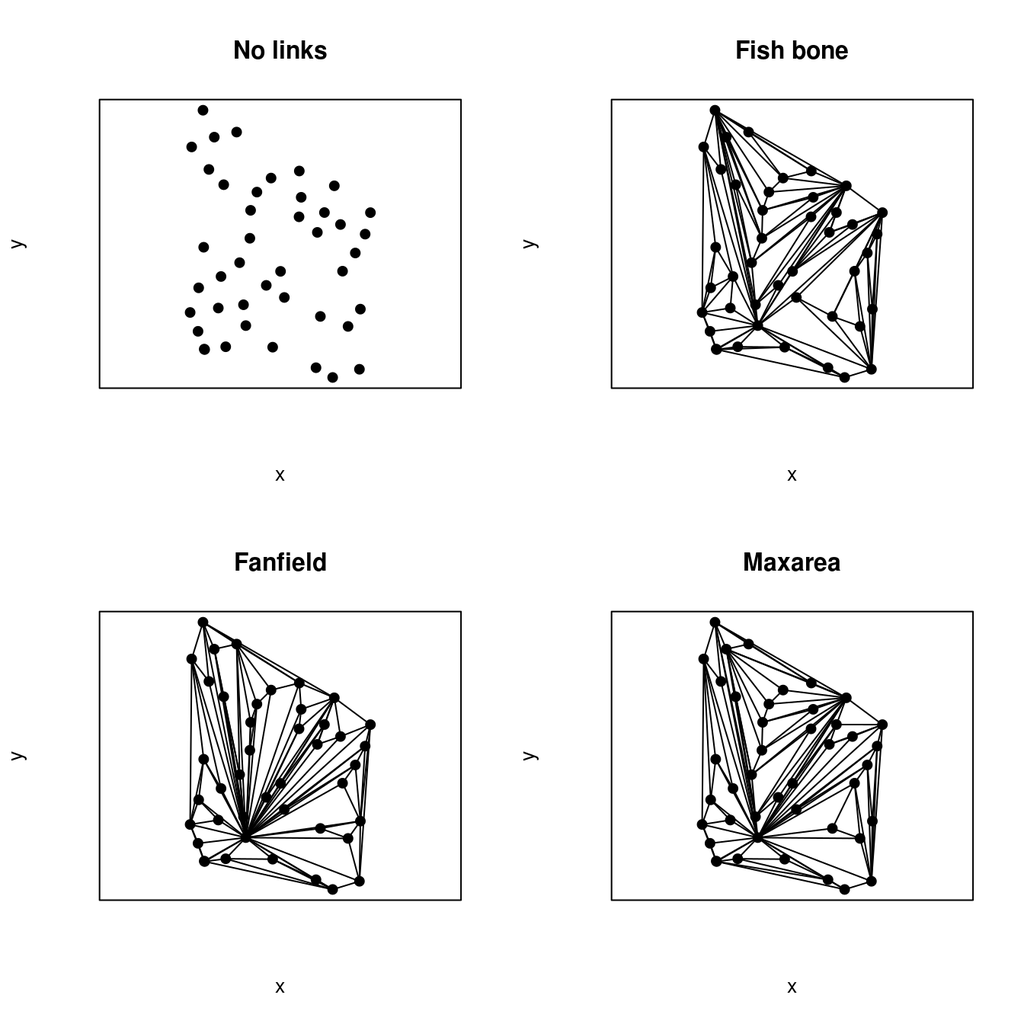

```r
library(ingressWeb)
# Read portal position from a Excel CSV file
path     <- system.file('shiny', 'data', package='ingressWeb')
filename <- paste(path, 'Leisepark-170212.csv', sep='/')
portals  <- read.csv(filename)
# convert latitude and longitude to x-y coordinates using the
# Universal Transverse Mercator coordinate system
xy   <- ll2xy(portals, utm=33)
web  <- ingressWeb(xy)
webb <- make.links(web, fishbone=33)
webf <- make.links(web, fanfield=33)
webm <- make.links(web, maxarea=33)
par(mfrow=c(2,2))
plot(web, main="No links")
plot(webb, main="Fish bone")
plot(webf, main="Fanfield")
plot(webm, main="Maxarea")
```

```r
# In Berlin you have approx. 0.021 MU/m^2 field
summary(webb, density=0.021)
```

```
##   portals     links min_field max_field    min_mu    max_mu
##        43       117        75       108       921      3538
```

```r
summary(webf, density=0.021)
```

```
##   portals     links min_field max_field    min_mu    max_mu
##        43       117        75       108       921      3334
```

```r
summary(webm, density=0.021)
```

```
##   portals     links min_field max_field    min_mu    max_mu
##        43       117        75       108       921      3917
```

And then for the most complex plan, the Cobweb:

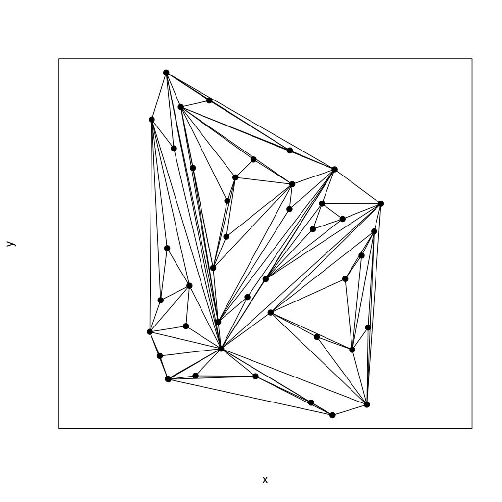

```r
# Read portal position from a Excel CSV file
path     <- system.file('shiny', 'data', package='ingressWeb')
filename <- paste(path, 'Leisepark-170212.csv', sep='/')
portals  <- read.csv(filename)
# convert latitude and longitude to x-y coordinates using the
# Universal Transverse Mercator coordinate system
xy   <- ll2xy(portals, utm=33)
web  <- ingressWeb(xy)
webc <- make.links(web, cobweb=33)
plot(webc)
```

```r
# In Berlin you have approx. 0.021 MU/m^2 field
summary(webc, density=0.021)
```

```
##   portals     links min_field max_field    min_mu    max_mu
##        43       117        75       108       921      3595
```

## Plot and query a web

### `summary`

You can query each a web for different informations: portals, links, fields, area of field (mind units). `summary` summarizes this information.

```r
set.seed(0)
library(ingressWeb)
web <- ingressWeb(random2(10))
summary(web)
```

```
##   portals     links min_field max_field    min_mu    max_mu
##        10         0         0         0         0         0
```

```r
web2 <- make.links(web)
summary(web2)
```

```
##   portals     links min_field max_field    min_mu    max_mu
##        10        24        15        16        38        76
```

### Specific queries

Functions are available for detailled information:

- `portals`,
- `links`,
- `fields`,
- `mindunits` (only rough estimates) and
- `acccesspoints` (only very very rough estimates)

```r
set.seed(0)
library(ingressWeb)
web  <- ingressWeb(random2(10))
web2 <- make.links(web, maxarea=10)
portals(web2)
```

```
## [1] 10
```

```r
links(web2)          # total number of links
```

```
## [1] 24
```

```r
l<-links(web2, TRUE) # number of links per portal
table(l)
```

```
## l
## 3 4 5 6 7 9
## 3 3 1 1 1 1
```

```r
fields(web2)         # with multilayers
```

```
## min_field max_field
##        15        22
```

```r
mindunits(web2)      # not rounded up
```

```
##    min_mu    max_mu
##  37.84231 140.50308
```

```r
accesspoints(web2)   #
```

```
## portal_ap    mod_ap   link_ap  field_ap
##     16250      2500      7512     27500
```

Note that `mindunits` and `accesspoints` are only rough estimates:

- `mindunits`:
  - `min_mu` gives the area of the fields (MU) if you make no multilayers and
  - `max_mu` gives the area of the fields (MU) if you make all possible multilayers.
- `accesspoints`:
  - `portal_ap` gives the AP you get if capture all portals and set always eight resonators,
  - `mod_ap` gives the AP if deploy each portal with two mods,
  - `link_ap` gives the AP if you make all links and
  - `field_ap` gives the AP if you make all fields.

The correct AP depends on various circumstances, e.g.

- which portals you have to capture,
- how many resonators and mods you will have to deplay and
- how many links and fields exists.

Not included are also the AP you get if you destroy portals, links, and fields from the opposite faction beforehand.

## Using the Shiny app

```r
install.packages(c('shiny', 'shinydashboard', 'shinyFiles'))
run
```

Then you just run

```r
library(ingressWeb)
shinyWeb()
```

### Creating or loading portals positions

The first step is to load portal positions or generate some. Either choose under `Web type` the choice `File` and click on `File select` if you want to load file (provided are the 43 portals of the [Leisepark in Berlin, Prenzlauer Berg](https://www.ingress.com/intel?ll=52.529774,13.421726&z=18). Or generate artificial portal positions, e.g. random, fishbone or cobweb positions.

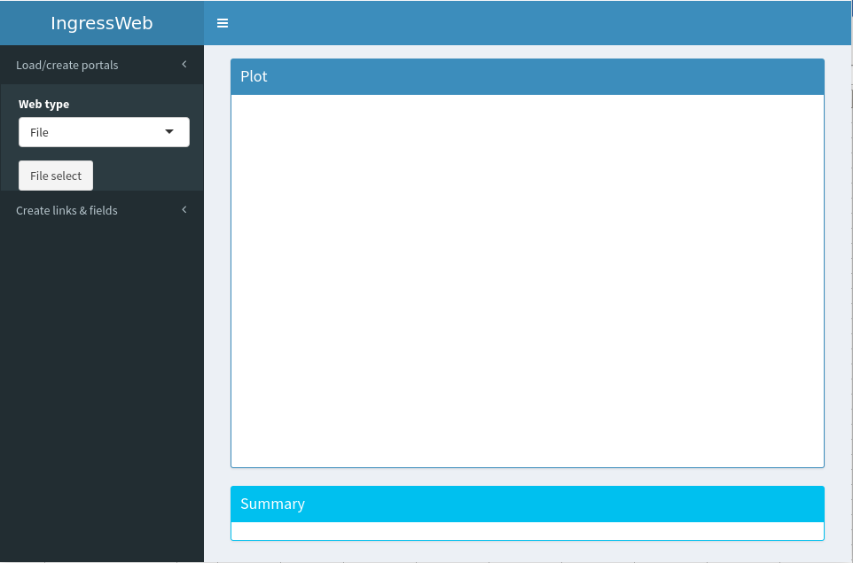

### Use a link plan

When the portal list is correctly loaded and converted to x-y coordinates then app should show the portal positions and a summary of the current linking plan. Since most linking plans require three outer portals, one portal (in red) is choosen as a base portal.

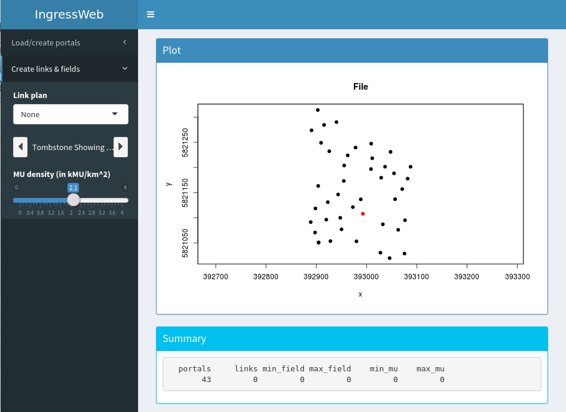

Under `Link plan` you may choose now a link plan and you will see in the plot the links and the summary of the web. The estimate of the MU depends on the MU density which is for Berlin approx. 2100 MU/km² field. You may change this with the slider. Note that choosing “0” with the slider will return the area in square meters covered by the fields.

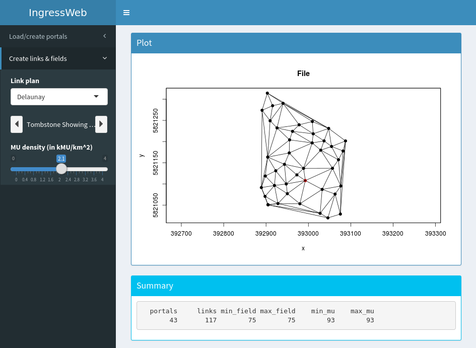

### Prepare your own portal postions

To include your own portal list you must create a (english) CSV file, (e.g. with LibreOffice Calc or Excel). The file must contain at least two columns: `lat` and `lon` (or `lng`) with the latitude and longitude of the portals. Additionally you can provide the columns `name` for the portal name and `shortname` which both uses the app. In the app the width for the portal name is limited, therefore for the short name a maximum length of approx. 20 characters is expected.

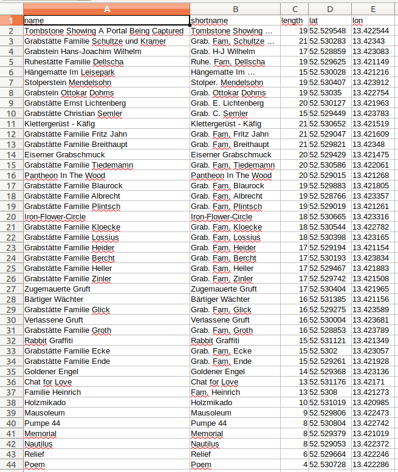

Place you data file into the directory given by

```r
 system.file("shiny", "data", package = "ingressWeb")
```